# Part II - (Analysis on Sales and Market Perfomance)

## by (David Kipngeno Kiplangat)

## Investigation Overview

> **Analysis task steps** the analysis of this task took an approach as indicate below equivalently.

> 1.Data understanding.

> ```
> - This phase i took time to load the data print a sample of the lines and computing basic
>   summary statistics to better understand the data.
> ```

> 2.Exploratory data analysis and visualization. This section covered the visualization of various variables and description of possible findings.

> 3.Explanatory data analysis. -the relationship in the data variables were identified, this was followed by attempt to explain the nature of the behaviour of the data.From this phase is where answering of most questions was done.

> 4.Conclusion and summary. This entailed the general findings from the data and the possible wisdom derivation from the data. An extensive report was produced providing the guidelines on the way to do the business and the best strategies to approach to better realize the companies goals and objectives

> **Analysis task steps** the analysis of this task took an approach as indicate below equivalently.

> 1.Data understanding.

> ```
> - This phase i took time to load the data print a sample of the lines and computing basic
>   summary atavistic to better understand the data.
> ```

> 2.Exploratory data analysis and visualization. -this section covered the visualization of various variables and description of possible findings.

> 3.Explanatory data analysis. -the relationship in the data variables were identified, this was followed by attempt to explain the nature of the behaviour of the data. From this phase is where answering of most questions was done.

> 4.Conclusion and summary. This entailed the general findings from the data and the possible wisdom derivation from the data. An extensive report was produced providing the guidelines on the way to do the business and the best strategies to approach to better realize the companies goals and objectives

## Dataset Overview

> The dataset employed for this task and analysis was originating from business setup environment. The Link to the data source is available : https://docs.google.com/spreadsheets/d/16F2awB6f0w-lWViGMgcEEgm5Xh4kigBkLGMsL_nbcnk/edit#gid=631415463 It is contains records of sales profits and items sold from different regions and segments and by different sales persons from a business environment.

|  | CustomerID | CustomerName | BusinessSegment | Country | Region | State | City | PostalCode | Order ID | Order Date | ... | Product Name | Price | Cost | Year | Month | Day | MarkedPrice | BuyingPrice | SellingPrice | Profit |
| --- | --- | --- | --- | --- | --- | --- | --- | --- | --- | --- | --- | --- | --- | --- | --- | --- | --- | --- | --- | --- | --- |
| 0 | A33717C73120 | Aaron Bergman | Consumer | United States | Central | Oklahoma | Oklahoma City | 73120 | CA-2013-140935 | 2020-11-11 | ... | Sauder Facets Collection Library, Sky Alder Fi... | 142.8000 | 74.764398 | 2020.0 | 11.0 | 13.0 | 142.8000 | 74.764398 | 142.8000 | 68.035602 |
| 1 | A33717C73120 | Aaron Bergman | Consumer | United States | Central | Oklahoma | Oklahoma City | 73120 | CA-2013-140935 | 2020-11-11 | ... | Samsung Convoy 3 | 76.4444 | 22.286997 | 2020.0 | 11.0 | 13.0 | 76.4444 | 22.286997 | 76.4444 | 54.157403 |
| 2 | A33717C76017 | Aaron Bergman | Consumer | United States | Central | Texas | Arlington | 76017 | CA-2011-152905 | 2018-02-19 | ... | Akro Stacking Bins | 7.1538 | 4.041695 | 2018.0 | 2.0 | 25.0 | 14.3076 | 8.083390 | 14.1076 | 6.024210 |
| 3 | A33717W98103 | Aaron Bergman | Consumer | United States | West | Washington | Seattle | 98103 | CA-2011-156587 | 2018-03-07 | ... | Carina 42"Hx23 3/4"W Media Storage Unit | 74.3636 | 41.543911 | 2018.0 | 3.0 | 8.0 | 223.0908 | 124.631732 | 223.0908 | 98.459068 |
| 4 | A33717W98103 | Aaron Bergman | Consumer | United States | West | Washington | Seattle | 98103 | CA-2011-156587 | 2018-03-07 | ... | Newell 330 | 5.4545 | 3.099148 | 2018.0 | 3.0 | 8.0 | 16.3635 | 9.297443 | 16.3635 | 7.066057 |

5 rows × 29 columns

**Sales By Profit** I was able to observe that the general sales as compared to profit had an intresting linear relationship. There was a significant positve relationship between the 2. sales made therefore can be said to directly influence the profit likely to meade. With this , it can be said that the sales of a product qualifies to be the predictor of that product as an increase of product sales leads to a corresponding increase of profit it generates.

**Cost By Price Performance** This was made to understand the behaviour of the business in terms of cost undertaken to produce the product and the reflexive amount the product is sold. it was discovered that the cost and price had a positive correlation between each other . A product that consume much resources to produce was equivalent sold at a higher price. This helped to bring a better plough back profit which considerably was the business return on investment. I was as well noted that a certain 2 products had extremely high cost of production and were as well sold at a quite huge price. This is as can be clearly observed in the visualizations below.

**Orders performance** there was none uniform distribution for orders that were made. As it can be observed, the were many orders of 1 and 5. This means that most orders made could not exceed 5 and that this range was the range that was affordably possible to most customers. This suggest that , probably the class purchasing or rather making orders is different. There were significance small orders exceeding 10. That is to say few customers can actually afford this amount and are forced to only within their reach.

**Most Sold Product** Staples was the most sold product followed by every none sticky Binders. This was suggestive that the consumers of the product were mostly office workers. or it could mean that there was a great demand to office furnishing. With the season, the best to invest in would be that one of staples.

**Best Performing Year By Profit** the year of 2021 was observed to be at pick of its performance in as far as profit income is considered. This could have be contributed by the marketing strategy employed by the sales persons which could have probably influenced the Purchase pattern of customers and thus attracted most profits.

## (Visualization)

This section showcases the visualization from which the findings and observations have been made in the above section.

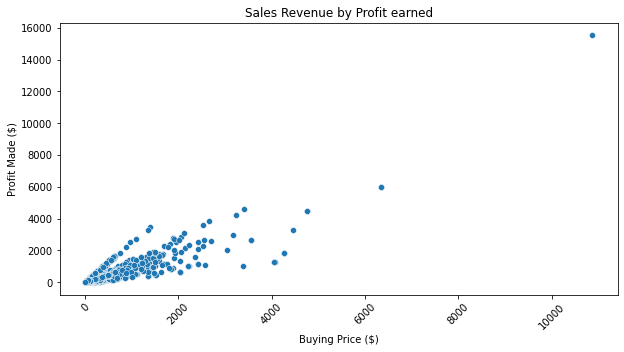

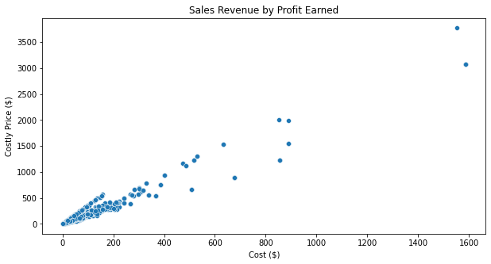

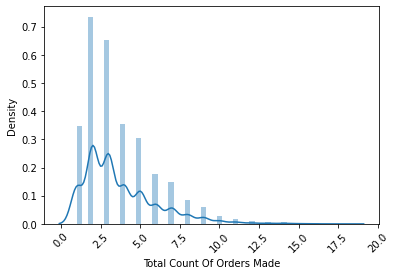

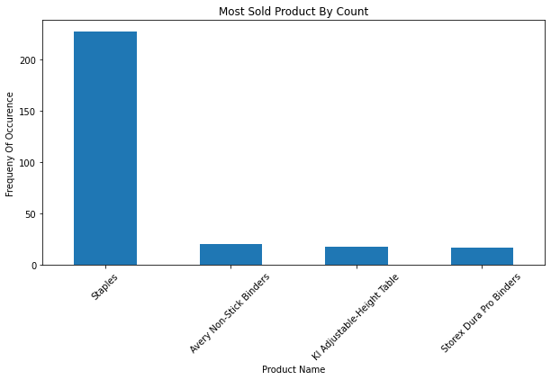

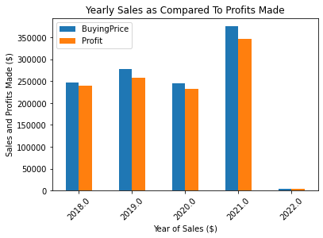

[output not shown]